# Análisis de datos

Just. Viol. Cambio. - Que estudiantes lancen piedras a carabineros

|  | Nunca se justifica (N=511) | Pocas veces se justifica (N=94) | Algunas veces se justifica (N=70) | Muchas veces se justifica (N=23) | Siempre se justifica (N=18) | Overall (N=716) |
| --- | --- | --- | --- | --- | --- | --- |
| Sentido de justicia obrero |  |  |  |  |  |  |
| Mean (SD) | -0.618 (0.416) | -0.703 (0.415) | -0.707 (0.470) | -0.665 (0.312) | -0.631 (0.329) | -0.640 (0.417) |
| Median [Min, Max] | -0.539 [-4.22, 1.72] | -0.609 [-2.53, 0] | -0.690 [-3.51, 0] | -0.511 [-1.61, -0.357] | -0.693 [-1.39, 0] | -0.560 [-4.22, 1.72] |
| Sentido de justicia CEO |  |  |  |  |  |  |
| Mean (SD) | 1.08 (0.877) | 1.04 (1.18) | 1.35 (1.30) | 1.50 (1.04) | 1.88 (1.25) | 1.13 (0.995) |
| Median [Min, Max] | 0.916 [-1.98, 5.30] | 0.916 [-5.01, 5.52] | 1.10 [-4.32, 4.38] | 1.39 [0, 3.69] | 1.74 [0, 4.09] | 0.916 [-5.01, 5.52] |
| Sentido de justicia entrevistado |  |  |  |  |  |  |
| Mean (SD) | -0.472 (0.413) | -0.521 (0.471) | -0.516 (0.307) | -0.507 (0.324) | -0.480 (0.590) | -0.484 (0.414) |
| Median [Min, Max] | -0.405 [-3.22, 0.182] | -0.468 [-2.30, 0.393] | -0.509 [-1.61, 0] | -0.470 [-1.43, 0] | -0.322 [-2.30, 0] | -0.405 [-3.22, 0.393] |

Just. Viol. Control - Carabineros reprima marchas

|  | Nunca se justifica (N=560) | Pocas veces se justifica (N=76) | Algunas veces se justifica (N=53) | Muchas veces se justifica (N=22) | Siempre se justifica (N=5) | Overall (N=716) |
| --- | --- | --- | --- | --- | --- | --- |
| Sentido de justicia obrero |  |  |  |  |  |  |
| Mean (SD) | -0.668 (0.426) | -0.514 (0.438) | -0.550 (0.257) | -0.586 (0.335) | -0.525 (0.399) | -0.640 (0.417) |
| Median [Min, Max] | -0.580 [-4.22, 1.10] | -0.511 [-2.30, 1.72] | -0.531 [-1.39, 0] | -0.542 [-1.43, 0] | -0.494 [-0.981, 0] | -0.560 [-4.22, 1.72] |
| Sentido de justicia CEO |  |  |  |  |  |  |
| Mean (SD) | 1.16 (1.00) | 0.973 (0.937) | 1.10 (1.02) | 1.19 (1.04) | 0.448 (0.365) | 1.13 (0.995) |
| Median [Min, Max] | 0.916 [-5.01, 5.52] | 0.693 [-0.981, 4.20] | 0.916 [-0.916, 5.30] | 0.981 [-0.511, 3.51] | 0.405 [0, 0.916] | 0.916 [-5.01, 5.52] |
| Sentido de justicia entrevistado |  |  |  |  |  |  |
| Mean (SD) | -0.501 (0.433) | -0.387 (0.265) | -0.428 (0.364) | -0.557 (0.463) | -0.340 (0.149) | -0.484 (0.414) |
| Median [Min, Max] | -0.430 [-3.22, 0.393] | -0.405 [-1.22, 0] | -0.357 [-1.43, 0.393] | -0.444 [-1.90, 0] | -0.288 [-0.542, -0.163] | -0.405 [-3.22, 0.393] |

Just. Viol. Control - Carabineros desaloje liceos en toma

|  | Nunca se justifica (N=457) | Pocas veces se justifica (N=118) | Algunas veces se justifica (N=90) | Muchas veces se justifica (N=30) | Siempre se justifica (N=21) | Overall (N=716) |
| --- | --- | --- | --- | --- | --- | --- |
| Sentido de justicia obrero |  |  |  |  |  |  |
| Mean (SD) | -0.688 (0.452) | -0.575 (0.391) | -0.565 (0.276) | -0.464 (0.226) | -0.524 (0.309) | -0.640 (0.417) |
| Median [Min, Max] | -0.603 [-4.22, 1.10] | -0.535 [-2.30, 1.72] | -0.545 [-1.43, 0.118] | -0.458 [-1.32, -0.134] | -0.494 [-1.02, 0] | -0.560 [-4.22, 1.72] |
| Sentido de justicia CEO |  |  |  |  |  |  |
| Mean (SD) | 1.20 (0.996) | 0.964 (1.04) | 1.09 (0.859) | 1.24 (1.23) | 0.745 (0.739) | 1.13 (0.995) |
| Median [Min, Max] | 0.916 [-4.32, 5.52] | 0.693 [-5.01, 4.09] | 0.981 [-0.916, 3.92] | 0.916 [0, 5.30] | 0.693 [0, 3.22] | 0.916 [-5.01, 5.52] |
| Sentido de justicia entrevistado |  |  |  |  |  |  |
| Mean (SD) | -0.526 (0.430) | -0.426 (0.407) | -0.423 (0.338) | -0.393 (0.311) | -0.305 (0.422) | -0.484 (0.414) |
| Median [Min, Max] | -0.462 [-3.22, 0.393] | -0.386 [-2.89, 0.393] | -0.357 [-1.43, 0.105] | -0.288 [-1.10, 0] | -0.206 [-1.90, 0] | -0.405 [-3.22, 0.393] |

Trato Respetuoso en Servicios de Salud

|  | Nunca (N=77) | Casi nunca (N=129) | A veces (N=303) | Casi siempre (N=152) | Siempre (N=55) | Overall (N=716) |
| --- | --- | --- | --- | --- | --- | --- |
| Sentido de justicia obrero |  |  |  |  |  |  |
| Mean (SD) | -0.723 (0.573) | -0.653 (0.413) | -0.621 (0.362) | -0.593 (0.350) | -0.724 (0.580) | -0.640 (0.417) |
| Median [Min, Max] | -0.580 [-4.22, 0.148] | -0.545 [-3.51, 0] | -0.539 [-2.81, 1.10] | -0.560 [-1.39, 1.72] | -0.654 [-3.62, 0.118] | -0.560 [-4.22, 1.72] |
| Sentido de justicia CEO |  |  |  |  |  |  |
| Mean (SD) | 1.27 (1.12) | 1.24 (0.934) | 1.08 (1.03) | 1.12 (0.967) | 1.06 (0.816) | 1.13 (0.995) |
| Median [Min, Max] | 1.10 [-1.98, 5.30] | 1.10 [-0.981, 4.20] | 0.916 [-5.01, 4.38] | 0.916 [-0.916, 5.52] | 0.773 [0, 3.92] | 0.916 [-5.01, 5.52] |
| Sentido de justicia entrevistado |  |  |  |  |  |  |
| Mean (SD) | -0.579 (0.464) | -0.509 (0.375) | -0.485 (0.449) | -0.423 (0.374) | -0.459 (0.307) | -0.484 (0.414) |
| Median [Min, Max] | -0.511 [-3.22, 0] | -0.457 [-1.90, 0.393] | -0.405 [-3.22, 0.393] | -0.344 [-2.12, 0] | -0.405 [-1.39, 0] | -0.405 [-3.22, 0.393] |

Trato Respetuoso por Carabineros

|  | Nunca (N=109) | Casi nunca (N=136) | A veces (N=259) | Casi siempre (N=131) | Siempre (N=81) | Overall (N=716) |
| --- | --- | --- | --- | --- | --- | --- |
| Sentido de justicia obrero |  |  |  |  |  |  |
| Mean (SD) | -0.714 (0.616) | -0.633 (0.319) | -0.606 (0.343) | -0.612 (0.366) | -0.701 (0.507) | -0.640 (0.417) |
| Median [Min, Max] | -0.606 [-4.22, 1.10] | -0.578 [-2.30, 0] | -0.539 [-2.30, 1.72] | -0.560 [-2.27, 0] | -0.603 [-3.62, 0.118] | -0.560 [-4.22, 1.72] |
| Sentido de justicia CEO |  |  |  |  |  |  |
| Mean (SD) | 1.27 (1.11) | 1.13 (1.23) | 1.12 (0.839) | 1.02 (0.900) | 1.21 (0.991) | 1.13 (0.995) |
| Median [Min, Max] | 1.20 [-1.98, 4.61] | 0.916 [-5.01, 5.52] | 0.916 [-1.20, 4.38] | 0.811 [-0.916, 4.09] | 0.916 [-0.693, 3.92] | 0.916 [-5.01, 5.52] |
| Sentido de justicia entrevistado |  |  |  |  |  |  |
| Mean (SD) | -0.589 (0.500) | -0.577 (0.506) | -0.455 (0.339) | -0.400 (0.377) | -0.418 (0.342) | -0.484 (0.414) |
| Median [Min, Max] | -0.511 [-3.22, 0] | -0.489 [-2.89, 0.393] | -0.405 [-2.12, 0.182] | -0.288 [-2.12, 0] | -0.357 [-1.61, 0.393] | -0.405 [-3.22, 0.393] |

|  | Hombre (N=339) | Mujer (N=377) | Overall (N=716) |
| --- | --- | --- | --- |
| Sentido de justicia obrero |  |  |  |
| Mean (SD) | -0.578 (0.386) | -0.694 (0.437) | -0.640 (0.417) |
| Median [Min, Max] | -0.511 [-4.22, 0] | -0.693 [-3.62, 1.72] | -0.560 [-4.22, 1.72] |
| Sentido de justicia CEO |  |  |  |
| Mean (SD) | 1.12 (1.04) | 1.15 (0.950) | 1.13 (0.995) |
| Median [Min, Max] | 0.916 [-5.01, 4.38] | 0.916 [-1.98, 5.52] | 0.916 [-5.01, 5.52] |
| Sentido de justicia entrevistado |  |  |  |
| Mean (SD) | -0.410 (0.351) | -0.551 (0.455) | -0.484 (0.414) |
| Median [Min, Max] | -0.357 [-2.71, 0.393] | -0.507 [-3.22, 0.393] | -0.405 [-3.22, 0.393] |

|  | Primaria incompleta menos (N=61) | Primaria y secundaria baja (N=50) | Secundaria alta (N=304) | Terciaria ciclo corto (N=134) | Terciaria y Postgrado (N=167) | Overall (N=716) |
| --- | --- | --- | --- | --- | --- | --- |
| Sentido de justicia obrero |  |  |  |  |  |  |
| Mean (SD) | -0.566 (0.540) | -0.616 (0.564) | -0.651 (0.391) | -0.620 (0.288) | -0.669 (0.448) | -0.640 (0.417) |
| Median [Min, Max] | -0.545 [-2.81, 1.72] | -0.525 [-3.51, 0.148] | -0.580 [-4.22, 0.118] | -0.539 [-1.79, 0] | -0.545 [-3.62, 0] | -0.560 [-4.22, 1.72] |
| Sentido de justicia CEO |  |  |  |  |  |  |
| Mean (SD) | 1.11 (1.08) | 1.15 (1.05) | 1.11 (1.08) | 1.18 (0.845) | 1.15 (0.915) | 1.13 (0.995) |
| Median [Min, Max] | 0.916 [-0.916, 5.52] | 0.973 [-1.98, 4.38] | 0.916 [-5.01, 5.30] | 0.916 [0, 4.09] | 0.916 [-0.916, 4.09] | 0.916 [-5.01, 5.52] |
| Sentido de justicia entrevistado |  |  |  |  |  |  |
| Mean (SD) | -0.546 (0.345) | -0.532 (0.506) | -0.526 (0.409) | -0.496 (0.476) | -0.362 (0.337) | -0.484 (0.414) |
| Median [Min, Max] | -0.511 [-1.61, 0] | -0.422 [-3.22, 0] | -0.457 [-2.71, 0] | -0.405 [-3.22, 0.393] | -0.310 [-1.79, 0.393] | -0.405 [-3.22, 0.393] |

|  | Totalmente insatisfecho (N=76) | Insatisfecho (N=341) | Ni satisfecho ni insatisfecho (N=107) | Satisfecho (N=170) | Totalmente satisfecho (N=22) | Overall (N=716) |
| --- | --- | --- | --- | --- | --- | --- |
| Sentido de justicia obrero |  |  |  |  |  |  |
| Mean (SD) | -0.790 (0.557) | -0.625 (0.411) | -0.617 (0.305) | -0.615 (0.413) | -0.639 (0.370) | -0.640 (0.417) |
| Median [Min, Max] | -0.693 [-4.22, 0] | -0.545 [-3.62, 1.72] | -0.539 [-1.90, 0] | -0.511 [-3.51, 0.118] | -0.570 [-1.71, 0] | -0.560 [-4.22, 1.72] |
| Sentido de justicia CEO |  |  |  |  |  |  |
| Mean (SD) | 1.22 (1.11) | 1.17 (1.00) | 1.03 (0.864) | 1.07 (1.02) | 1.31 (0.912) | 1.13 (0.995) |
| Median [Min, Max] | 1.01 [-4.32, 3.91] | 0.916 [-1.98, 5.52] | 0.811 [-0.916, 4.27] | 0.916 [-5.01, 4.09] | 1.15 [0, 4.09] | 0.916 [-5.01, 5.52] |
| Sentido de justicia entrevistado |  |  |  |  |  |  |
| Mean (SD) | -0.711 (0.374) | -0.581 (0.407) | -0.440 (0.368) | -0.275 (0.360) | -0.0450 (0.189) | -0.484 (0.414) |
| Median [Min, Max] | -0.596 [-1.79, -0.0426] | -0.511 [-3.22, 0.182] | -0.357 [-2.30, 0] | -0.223 [-3.22, 0.393] | 0 [-0.511, 0.393] | -0.405 [-3.22, 0.393] |

### Bivariados trato respetuoso (H2)

|  | Nunca (N=77) | Casi nunca (N=129) | A veces (N=303) | Casi siempre (N=152) | Siempre (N=55) | Overall (N=716) |
| --- | --- | --- | --- | --- | --- | --- |
| Indice sumativo de justificación de daño a la propiedad |  |  |  |  |  |  |
| Mean (SD) | 4.47 (3.08) | 3.66 (1.55) | 3.65 (1.58) | 3.76 (2.03) | 4.20 (2.34) | 3.80 (1.96) |
| Median [Min, Max] | 3.00 [3.00, 15.0] | 3.00 [3.00, 10.0] | 3.00 [3.00, 15.0] | 3.00 [3.00, 15.0] | 3.00 [3.00, 13.0] | 3.00 [3.00, 15.0] |

|  | Nunca (N=109) | Casi nunca (N=136) | A veces (N=259) | Casi siempre (N=131) | Siempre (N=81) | Overall (N=716) |
| --- | --- | --- | --- | --- | --- | --- |
| Indice sumativo de justificación de daño a la propiedad |  |  |  |  |  |  |
| Mean (SD) | 4.49 (2.76) | 3.82 (1.87) | 3.67 (1.70) | 3.63 (1.81) | 3.56 (1.69) | 3.80 (1.96) |
| Median [Min, Max] | 3.00 [3.00, 15.0] | 3.00 [3.00, 15.0] | 3.00 [3.00, 13.0] | 3.00 [3.00, 15.0] | 3.00 [3.00, 12.0] | 3.00 [3.00, 15.0] |

| Justificación violencia: Estudiantes tiren piedras | Trato respetuoso en servicios de salud |  |  |  |  | Total |  |
| --- | --- | --- | --- | --- | --- | --- | --- |
|  | Nunca | Casi nunca | A veces | Casi siempre | Siempre |  |  |
| Nunca se justifica | 47 61 % | 94 72.9 % | 217 71.6 % | 113 74.3 % | 40 72.7 % |  | 511 71.4 % |
| Pocas veces se justifica | 6 7.8 % | 17 13.2 % | 45 14.9 % | 21 13.8 % | 5 9.1 % | 94 13.1 % |  |
| Algunas veces se justifica | 11 14.3 % | 10 7.8 % | 30 9.9 % | 13 8.6 % | 6 10.9 % | 70 9.8 % |  |
| Muchas veces se justifica | 5 6.5 % | 5 3.9 % | 9 3 % | 1 0.7 % | 3 5.5 % | 23 3.2 % |  |
| Siempre se justifica | 8 10.4 % | 3 2.3 % | 2 0.7 % | 4 2.6 % | 1 1.8 % | 18 2.5 % |  |
| Total | 77 100 % | 129 100 % | 303 100 % | 152 100 % | 55 100 % | 716 100 % |  |

| Justificación violencia: Estudiantes tiren piedras | Trato respetuoso por parte de carabineros |  |  |  |  | Total |  |
| --- | --- | --- | --- | --- | --- | --- | --- |
|  | Nunca | Casi nunca | A veces | Casi siempre | Siempre |  |  |
| Nunca se justifica | 58 53.2 % | 90 66.2 % | 188 72.6 % | 107 81.7 % | 68 84 % |  | 511 71.4 % |
| Pocas veces se justifica | 13 11.9 % | 26 19.1 % | 40 15.4 % | 13 9.9 % | 2 2.5 % | 94 13.1 % |  |
| Algunas veces se justifica | 19 17.4 % | 11 8.1 % | 24 9.3 % | 9 6.9 % | 7 8.6 % | 70 9.8 % |  |
| Muchas veces se justifica | 6 5.5 % | 7 5.1 % | 5 1.9 % | 1 0.8 % | 4 4.9 % | 23 3.2 % |  |
| Siempre se justifica | 13 11.9 % | 2 1.5 % | 2 0.8 % | 1 0.8 % | 0 0 % | 18 2.5 % |  |
| Total | 109 100 % | 136 100 % | 259 100 % | 131 100 % | 81 100 % | 716 100 % |  |

| Justificación violencia: Carabineros reprime marchas | Trato respetuoso en servicios de salud |  |  |  |  | Total |  |
| --- | --- | --- | --- | --- | --- | --- | --- |
|  | Nunca | Casi nunca | A veces | Casi siempre | Siempre |  |  |
| Nunca se justifica | 70 90.9 % | 98 76 % | 240 79.2 % | 110 72.4 % | 42 76.4 % |  | 560 78.2 % |
| Pocas veces se justifica | 3 3.9 % | 18 14 % | 31 10.2 % | 19 12.5 % | 5 9.1 % | 76 10.6 % |  |
| Algunas veces se justifica | 2 2.6 % | 10 7.8 % | 23 7.6 % | 13 8.6 % | 5 9.1 % | 53 7.4 % |  |
| Muchas veces se justifica | 2 2.6 % | 2 1.6 % | 7 2.3 % | 9 5.9 % | 2 3.6 % | 22 3.1 % |  |
| Siempre se justifica | 0 0 % | 1 0.8 % | 2 0.7 % | 1 0.7 % | 1 1.8 % | 5 0.7 % |  |
| Total | 77 100 % | 129 100 % | 303 100 % | 152 100 % | 55 100 % | 716 100 % |  |

| Justificación violencia: Carabineros reprime marchas | Trato respetuoso por parte de carabineros |  |  |  |  | Total |  |
| --- | --- | --- | --- | --- | --- | --- | --- |
|  | Nunca | Casi nunca | A veces | Casi siempre | Siempre |  |  |
| Nunca se justifica | 94 86.2 % | 114 83.8 % | 198 76.4 % | 96 73.3 % | 58 71.6 % |  | 560 78.2 % |
| Pocas veces se justifica | 9 8.3 % | 7 5.1 % | 33 12.7 % | 17 13 % | 10 12.3 % | 76 10.6 % |  |
| Algunas veces se justifica | 5 4.6 % | 13 9.6 % | 17 6.6 % | 11 8.4 % | 7 8.6 % | 53 7.4 % |  |
| Muchas veces se justifica | 1 0.9 % | 2 1.5 % | 9 3.5 % | 5 3.8 % | 5 6.2 % | 22 3.1 % |  |
| Siempre se justifica | 0 0 % | 0 0 % | 2 0.8 % | 2 1.5 % | 1 1.2 % | 5 0.7 % |  |
| Total | 109 100 % | 136 100 % | 259 100 % | 131 100 % | 81 100 % | 716 100 % |  |

| Justificación violencia: Carabineros desaloja liceos en toma | Trato respetuoso en servicios de salud |  |  |  |  | Total |  |
| --- | --- | --- | --- | --- | --- | --- | --- |
|  | Nunca | Casi nunca | A veces | Casi siempre | Siempre |  |  |
| Nunca se justifica | 65 84.4 % | 82 63.6 % | 193 63.7 % | 88 57.9 % | 29 52.7 % |  | 457 63.8 % |
| Pocas veces se justifica | 4 5.2 % | 20 15.5 % | 55 18.2 % | 27 17.8 % | 12 21.8 % | 118 16.5 % |  |
| Algunas veces se justifica | 2 2.6 % | 19 14.7 % | 41 13.5 % | 20 13.2 % | 8 14.5 % | 90 12.6 % |  |
| Muchas veces se justifica | 4 5.2 % | 5 3.9 % | 9 3 % | 10 6.6 % | 2 3.6 % | 30 4.2 % |  |
| Siempre se justifica | 2 2.6 % | 3 2.3 % | 5 1.7 % | 7 4.6 % | 4 7.3 % | 21 2.9 % |  |
| Total | 77 100 % | 129 100 % | 303 100 % | 152 100 % | 55 100 % | 716 100 % |  |

| Justificación violencia: Carabineros desaloja liceos en toma | Trato respetuoso por parte de carabineros |  |  |  |  | Total |  |
| --- | --- | --- | --- | --- | --- | --- | --- |
|  | Nunca | Casi nunca | A veces | Casi siempre | Siempre |  |  |
| Nunca se justifica | 93 85.3 % | 96 70.6 % | 155 59.8 % | 70 53.4 % | 43 53.1 % |  | 457 63.8 % |
| Pocas veces se justifica | 8 7.3 % | 23 16.9 % | 55 21.2 % | 24 18.3 % | 8 9.9 % | 118 16.5 % |  |
| Algunas veces se justifica | 6 5.5 % | 11 8.1 % | 34 13.1 % | 24 18.3 % | 15 18.5 % | 90 12.6 % |  |
| Muchas veces se justifica | 2 1.8 % | 4 2.9 % | 9 3.5 % | 6 4.6 % | 9 11.1 % | 30 4.2 % |  |
| Siempre se justifica | 0 0 % | 2 1.5 % | 6 2.3 % | 7 5.3 % | 6 7.4 % | 21 2.9 % |  |
| Total | 109 100 % | 136 100 % | 259 100 % | 131 100 % | 81 100 % | 716 100 % |  |

### Bivariados grupos desventajados (H3)

|  | Hombre (N=339) | Mujer (N=377) | Overall (N=716) |
| --- | --- | --- | --- |
| Indice sumativo de justificación de daño a la propiedad |  |  |  |
| Mean (SD) | 3.91 (2.10) | 3.71 (1.83) | 3.80 (1.96) |
| Median [Min, Max] | 3.00 [3.00, 15.0] | 3.00 [3.00, 15.0] | 3.00 [3.00, 15.0] |

| Justificación violencia: Estudiantes tiren piedras | Sexo del entrevistado |  | Total |  |
| --- | --- | --- | --- | --- |
|  | Hombre | Mujer |  |  |
| Nunca se justifica | 231 68.1 % | 280 74.3 % |  | 511 71.4 % |
| Pocas veces se justifica | 46 13.6 % | 48 12.7 % | 94 13.1 % |  |
| Algunas veces se justifica | 34 10 % | 36 9.5 % | 70 9.8 % |  |
| Muchas veces se justifica | 13 3.8 % | 10 2.7 % | 23 3.2 % |  |
| Siempre se justifica | 15 4.4 % | 3 0.8 % | 18 2.5 % |  |
| Total | 339 100 % | 377 100 % | 716 100 % |  |

| Justificación violencia: Carabineros reprime marchas | Sexo del entrevistado |  | Total |  |
| --- | --- | --- | --- | --- |
|  | Hombre | Mujer |  |  |
| Nunca se justifica | 251 74 % | 309 82 % |  | 560 78.2 % |
| Pocas veces se justifica | 48 14.2 % | 28 7.4 % | 76 10.6 % |  |
| Algunas veces se justifica | 26 7.7 % | 27 7.2 % | 53 7.4 % |  |
| Muchas veces se justifica | 11 3.2 % | 11 2.9 % | 22 3.1 % |  |
| Siempre se justifica | 3 0.9 % | 2 0.5 % | 5 0.7 % |  |
| Total | 339 100 % | 377 100 % | 716 100 % |  |

| Justificación violencia: Carabineros desaloja liceos en toma | Sexo del entrevistado |  | Total |  |
| --- | --- | --- | --- | --- |
|  | Hombre | Mujer |  |  |
| Nunca se justifica | 198 58.4 % | 259 68.7 % |  | 457 63.8 % |
| Pocas veces se justifica | 64 18.9 % | 54 14.3 % | 118 16.5 % |  |
| Algunas veces se justifica | 50 14.7 % | 40 10.6 % | 90 12.6 % |  |
| Muchas veces se justifica | 13 3.8 % | 17 4.5 % | 30 4.2 % |  |
| Siempre se justifica | 14 4.1 % | 7 1.9 % | 21 2.9 % |  |
| Total | 339 100 % | 377 100 % | 716 100 % |  |

|  | Primaria incompleta menos (N=61) | Primaria y secundaria baja (N=50) | Secundaria alta (N=304) | Terciaria ciclo corto (N=134) | Terciaria y Postgrado (N=167) | Overall (N=716) |
| --- | --- | --- | --- | --- | --- | --- |
| Indice sumativo de justificación de daño a la propiedad |  |  |  |  |  |  |
| Mean (SD) | 3.62 (1.98) | 3.70 (2.38) | 3.65 (1.82) | 3.86 (1.79) | 4.14 (2.18) | 3.80 (1.96) |
| Median [Min, Max] | 3.00 [3.00, 13.0] | 3.00 [3.00, 15.0] | 3.00 [3.00, 15.0] | 3.00 [3.00, 10.0] | 3.00 [3.00, 15.0] | 3.00 [3.00, 15.0] |

| Justificación violencia: Estudiantes tiren piedras | Nivel educacional CINE del entrevistado |  |  |  |  | Total |  |
| --- | --- | --- | --- | --- | --- | --- | --- |
|  | Primaria incompleta menos | Primaria y secundaria baja | Secundaria alta | Terciaria ciclo corto | Terciaria y Postgrado |  |  |
| Nunca se justifica | 46 75.4 % | 35 70 % | 215 70.7 % | 100 74.6 % | 115 68.9 % |  | 511 71.4 % |
| Pocas veces se justifica | 8 13.1 % | 7 14 % | 39 12.8 % | 14 10.4 % | 26 15.6 % | 94 13.1 % |  |
| Algunas veces se justifica | 4 6.6 % | 6 12 % | 32 10.5 % | 12 9 % | 16 9.6 % | 70 9.8 % |  |
| Muchas veces se justifica | 1 1.6 % | 0 0 % | 11 3.6 % | 5 3.7 % | 6 3.6 % | 23 3.2 % |  |
| Siempre se justifica | 2 3.3 % | 2 4 % | 7 2.3 % | 3 2.2 % | 4 2.4 % | 18 2.5 % |  |
| Total | 61 100 % | 50 100 % | 304 100 % | 134 100 % | 167 100 % | 716 100 % |  |

| Justificación violencia: Carabineros reprime marchas | Nivel educacional CINE del entrevistado |  |  |  |  | Total |  |
| --- | --- | --- | --- | --- | --- | --- | --- |
|  | Primaria incompleta menos | Primaria y secundaria baja | Secundaria alta | Terciaria ciclo corto | Terciaria y Postgrado |  |  |
| Nunca se justifica | 36 59 % | 40 80 % | 247 81.2 % | 106 79.1 % | 131 78.4 % |  | 560 78.2 % |
| Pocas veces se justifica | 6 9.8 % | 7 14 % | 27 8.9 % | 17 12.7 % | 19 11.4 % | 76 10.6 % |  |
| Algunas veces se justifica | 12 19.7 % | 0 0 % | 20 6.6 % | 9 6.7 % | 12 7.2 % | 53 7.4 % |  |
| Muchas veces se justifica | 5 8.2 % | 3 6 % | 10 3.3 % | 2 1.5 % | 2 1.2 % | 22 3.1 % |  |
| Siempre se justifica | 2 3.3 % | 0 0 % | 0 0 % | 0 0 % | 3 1.8 % | 5 0.7 % |  |
| Total | 61 100 % | 50 100 % | 304 100 % | 134 100 % | 167 100 % | 716 100 % |  |

| Justificación violencia: Carabineros desaloja liceos en toma | Nivel educacional CINE del entrevistado |  |  |  |  | Total |  |
| --- | --- | --- | --- | --- | --- | --- | --- |
|  | Primaria incompleta menos | Primaria y secundaria baja | Secundaria alta | Terciaria ciclo corto | Terciaria y Postgrado |  |  |
| Nunca se justifica | 34 55.7 % | 38 76 % | 202 66.4 % | 84 62.7 % | 99 59.3 % |  | 457 63.8 % |
| Pocas veces se justifica | 12 19.7 % | 5 10 % | 49 16.1 % | 18 13.4 % | 34 20.4 % | 118 16.5 % |  |
| Algunas veces se justifica | 7 11.5 % | 4 8 % | 38 12.5 % | 22 16.4 % | 19 11.4 % | 90 12.6 % |  |
| Muchas veces se justifica | 6 9.8 % | 3 6 % | 8 2.6 % | 7 5.2 % | 6 3.6 % | 30 4.2 % |  |
| Siempre se justifica | 2 3.3 % | 0 0 % | 7 2.3 % | 3 2.2 % | 9 5.4 % | 21 2.9 % |  |
| Total | 61 100 % | 50 100 % | 304 100 % | 134 100 % | 167 100 % | 716 100 % |  |

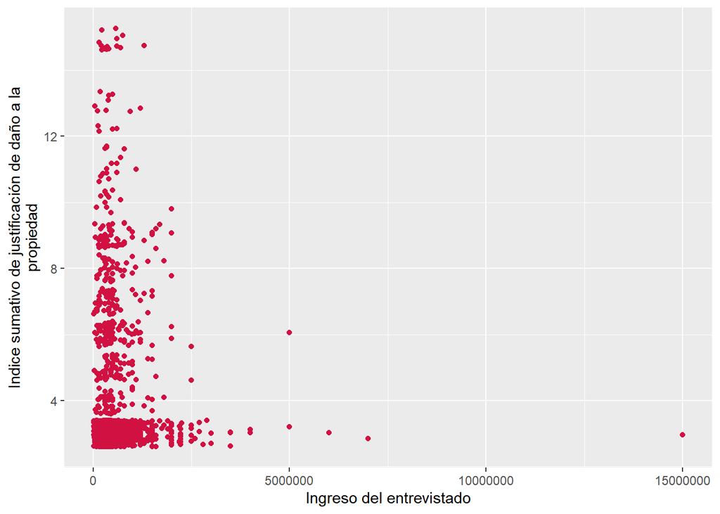

|  | Nunca se justifica (N=511) | Pocas veces se justifica (N=94) | Algunas veces se justifica (N=70) | Muchas veces se justifica (N=23) | Siempre se justifica (N=18) | Overall (N=716) |
| --- | --- | --- | --- | --- | --- | --- |
| Ingreso del entrevistado |  |  |  |  |  |  |
| Mean (SD) | 565000 (823000) | 527000 (386000) | 504000 (510000) | 593000 (424000) | 588000 (441000) | 556000 (734000) |
| Median [Min, Max] | 400000 [20000, 15000000] | 450000 [50000, 2220000] | 350000 [40000, 3000000] | 500000 [120000, 2000000] | 525000 [100000, 2000000] | 400000 [20000, 15000000] |

|  | Nunca se justifica (N=560) | Pocas veces se justifica (N=76) | Algunas veces se justifica (N=53) | Muchas veces se justifica (N=22) | Siempre se justifica (N=5) | Overall (N=716) |
| --- | --- | --- | --- | --- | --- | --- |
| Ingreso del entrevistado |  |  |  |  |  |  |
| Mean (SD) | 542000 (518000) | 532000 (316000) | 814000 (2060000) | 369000 (294000) | 485000 (346000) | 556000 (734000) |
| Median [Min, Max] | 400000 [20000, 7000000] | 495000 [20000, 2000000] | 400000 [60000, 15000000] | 310000 [20000, 1050000] | 340000 [285000, 1100000] | 400000 [20000, 15000000] |

|  | Nunca se justifica (N=457) | Pocas veces se justifica (N=118) | Algunas veces se justifica (N=90) | Muchas veces se justifica (N=30) | Siempre se justifica (N=21) | Overall (N=716) |
| --- | --- | --- | --- | --- | --- | --- |
| Ingreso del entrevistado |  |  |  |  |  |  |
| Mean (SD) | 499000 (395000) | 585000 (458000) | 631000 (864000) | 520000 (441000) | 1350000 (3180000) | 556000 (734000) |
| Median [Min, Max] | 400000 [20000, 2700000] | 450000 [40000, 3000000] | 400000 [60000, 7000000] | 410000 [20000, 2000000] | 500000 [150000, 15000000] | 400000 [20000, 15000000] |

|  | Totalmente insatisfecho (N=76) | Insatisfecho (N=341) | Ni satisfecho ni insatisfecho (N=107) | Satisfecho (N=170) | Totalmente satisfecho (N=22) | Overall (N=716) |
| --- | --- | --- | --- | --- | --- | --- |
| Indice sumativo de justificación de daño a la propiedad |  |  |  |  |  |  |
| Mean (SD) | 4.08 (2.62) | 3.71 (1.69) | 4.15 (2.43) | 3.63 (1.63) | 3.95 (2.84) | 3.80 (1.96) |
| Median [Min, Max] | 3.00 [3.00, 15.0] | 3.00 [3.00, 13.0] | 3.00 [3.00, 15.0] | 3.00 [3.00, 13.0] | 3.00 [3.00, 15.0] | 3.00 [3.00, 15.0] |

| Justificación violencia: Estudiantes tiren piedras | Satisfacción con los ingresos |  |  |  |  | Total |  |
| --- | --- | --- | --- | --- | --- | --- | --- |
|  | Totalmente insatisfecho | Insatisfecho | Ni satisfecho ni insatisfecho | Satisfecho | Totalmente satisfecho |  |  |
| Nunca se justifica | 49 64.5 % | 247 72.4 % | 70 65.4 % | 129 75.9 % | 16 72.7 % |  | 511 71.4 % |
| Pocas veces se justifica | 11 14.5 % | 42 12.3 % | 22 20.6 % | 17 10 % | 2 9.1 % | 94 13.1 % |  |
| Algunas veces se justifica | 12 15.8 % | 35 10.3 % | 8 7.5 % | 14 8.2 % | 1 4.5 % | 70 9.8 % |  |
| Muchas veces se justifica | 2 2.6 % | 11 3.2 % | 5 4.7 % | 5 2.9 % | 0 0 % | 23 3.2 % |  |
| Siempre se justifica | 2 2.6 % | 6 1.8 % | 2 1.9 % | 5 2.9 % | 3 13.6 % | 18 2.5 % |  |
| Total | 76 100 % | 341 100 % | 107 100 % | 170 100 % | 22 100 % | 716 100 % |  |

| Justificación violencia: Carabineros reprime marchas | Satisfacción con los ingresos |  |  |  |  | Total |  |
| --- | --- | --- | --- | --- | --- | --- | --- |
|  | Totalmente insatisfecho | Insatisfecho | Ni satisfecho ni insatisfecho | Satisfecho | Totalmente satisfecho |  |  |
| Nunca se justifica | 62 81.6 % | 274 80.4 % | 80 74.8 % | 128 75.3 % | 16 72.7 % |  | 560 78.2 % |
| Pocas veces se justifica | 6 7.9 % | 32 9.4 % | 15 14 % | 23 13.5 % | 0 0 % | 76 10.6 % |  |
| Algunas veces se justifica | 6 7.9 % | 20 5.9 % | 10 9.3 % | 12 7.1 % | 5 22.7 % | 53 7.4 % |  |
| Muchas veces se justifica | 2 2.6 % | 13 3.8 % | 1 0.9 % | 5 2.9 % | 1 4.5 % | 22 3.1 % |  |
| Siempre se justifica | 0 0 % | 2 0.6 % | 1 0.9 % | 2 1.2 % | 0 0 % | 5 0.7 % |  |
| Total | 76 100 % | 341 100 % | 107 100 % | 170 100 % | 22 100 % | 716 100 % |  |

| Justificación violencia: Carabineros desaloja liceos en toma | Satisfacción con los ingresos |  |  |  |  | Total |  |
| --- | --- | --- | --- | --- | --- | --- | --- |
|  | Totalmente insatisfecho | Insatisfecho | Ni satisfecho ni insatisfecho | Satisfecho | Totalmente satisfecho |  |  |
| Nunca se justifica | 58 76.3 % | 224 65.7 % | 69 64.5 % | 93 54.7 % | 13 59.1 % |  | 457 63.8 % |
| Pocas veces se justifica | 7 9.2 % | 58 17 % | 20 18.7 % | 31 18.2 % | 2 9.1 % | 118 16.5 % |  |
| Algunas veces se justifica | 9 11.8 % | 39 11.4 % | 9 8.4 % | 30 17.6 % | 3 13.6 % | 90 12.6 % |  |
| Muchas veces se justifica | 1 1.3 % | 12 3.5 % | 5 4.7 % | 11 6.5 % | 1 4.5 % | 30 4.2 % |  |
| Siempre se justifica | 1 1.3 % | 8 2.3 % | 4 3.7 % | 5 2.9 % | 3 13.6 % | 21 2.9 % |  |
| Total | 76 100 % | 341 100 % | 107 100 % | 170 100 % | 22 100 % | 716 100 % |  |

### Correlaciones entre variables dependientes y sense of justice (H1)

|  | Justificacion de violencia: Carabineros reprima marchas (2019) | Justificacion de violencia: Carabineros desaloje liceos en toma (2019) | Justificacion de violencia: Estudiantes tiren piedras (2019) | Indice sumativo de justificación de daño a la propiedad | Sentido de justicia CEO | Sentido de justicia obrero | Sentido de justicia entrevistado |
| --- | --- | --- | --- | --- | --- | --- | --- |
| Justificacion de violencia: Carabineros reprima marchas (2019) |  |  |  |  |  |  |  |
| Justificacion de violencia: Carabineros desaloje liceos en toma (2019) | 0.506*** |  |  |  |  |  |  |
| Justificacion de violencia: Estudiantes tiren piedras (2019) | -0.070 | -0.120** |  |  |  |  |  |
| Indice sumativo de justificación de daño a la propiedad | 0.048 | -0.023 | 0.466*** |  |  |  |  |
| Sentido de justicia CEO | -0.045 | -0.069 | 0.144*** | 0.114** |  |  |  |
| Sentido de justicia obrero | 0.104** | 0.150*** | -0.057 | -0.129*** | -0.132*** |  |  |
| Sentido de justicia entrevistado | 0.048 | 0.134*** | -0.032 | -0.000 | -0.078* | 0.116** |  |
| Computed correlation used pearson-method with listwise-deletion. |  |  |  |  |  |  |  |

### Correlaciones entre variables dpendientes y trato justo (H2)

|  | Justificacion de violencia: Carabineros reprima marchas (2019) | Justificacion de violencia: Carabineros desaloje liceos en toma (2019) | Justificacion de violencia: Estudiantes tiren piedras (2019) | Indice sumativo de justificación de daño a la propiedad | Frecuencia: Trato respetuoso en servicios de salud a [CLASE] (2019) | Frecuencia: Trato respetuoso por Carabineros a [CLASE] (2019) |
| --- | --- | --- | --- | --- | --- | --- |
| Justificacion de violencia: Carabineros reprima marchas (2019) |  |  |  |  |  |  |
| Justificacion de violencia: Carabineros desaloje liceos en toma (2019) | 0.506*** |  |  |  |  |  |
| Justificacion de violencia: Estudiantes tiren piedras (2019) | -0.070 | -0.120** |  |  |  |  |
| Indice sumativo de justificación de daño a la propiedad | 0.048 | -0.023 | 0.466*** |  |  |  |
| Frecuencia: Trato respetuoso en servicios de salud a [CLASE] (2019) | 0.098** | 0.124*** | -0.104** | -0.032 |  |  |
| Frecuencia: Trato respetuoso por Carabineros a [CLASE] (2019) | 0.127*** | 0.247*** | -0.233*** | -0.128*** | 0.491*** |  |
| Computed correlation used pearson-method with listwise-deletion. |  |  |  |  |  |  |

### Correlaciones entre variables dependientes y grupos desventajados (H3)

|  | Justificacion de violencia: Carabineros reprima marchas (2019) | Justificacion de violencia: Carabineros desaloje liceos en toma (2019) | Justificacion de violencia: Estudiantes tiren piedras (2019) | Indice sumativo de justificación de daño a la propiedad | Sexo del entrevistado (2019) | Nivel educacional CINE del entrevistado | Ingreso del entrevistado | Satisfaccion con ingreso (2019) |
| --- | --- | --- | --- | --- | --- | --- | --- | --- |
| Justificacion de violencia: Carabineros reprima marchas (2019) |  |  |  |  |  |  |  |  |
| Justificacion de violencia: Carabineros desaloje liceos en toma (2019) | 0.506*** |  |  |  |  |  |  |  |
| Justificacion de violencia: Estudiantes tiren piedras (2019) | -0.070 | -0.120** |  |  |  |  |  |  |
| Indice sumativo de justificación de daño a la propiedad | 0.048 | -0.023 | 0.466*** |  |  |  |  |  |
| Sexo del entrevistado (2019) | -0.063 | -0.096* | -0.102** | -0.050 |  |  |  |  |
| Nivel educacional CINE del entrevistado | -0.104** | 0.030 | 0.016 | 0.089* | -0.002 |  |  |  |
| Ingreso del entrevistado | 0.028 | 0.148*** | -0.010 | -0.027 | -0.161*** | 0.301*** |  |  |
| Satisfaccion con ingreso (2019) | 0.055 | 0.135*** | -0.012 | -0.022 | -0.146*** | 0.239*** | 0.323*** |  |
| Computed correlation used pearson-method with listwise-deletion. |  |  |  |  |  |  |  |  |

## Seccion multivariada

Indice de destrucción a la propiedad

Regresiones lineales simples - Indice de destruccion a la propiedad

Modelo 1

Modelo 2

Modelo 3

Modelo 4

Predictores

ß

ß

ß

(Intercept)

3.44 ***

4.00 ***

3.47 ***

Sentido de justicia CEO:  
Subrecompensado

0.21

Sentido de justicia CEO:  
Sobrerecompensado

0.40

Sentido de justicia  
obrero: Subrecompensado

-0.20

Sentido de justicia  
obrero: Sobrerecompensado

-1.00

Sentido de justicia  
entrevistado:  
Subrecompensado

0.38

Sentido de justicia  
entrevistado:  
Sobrerecompensado

-0.47

Observations

716

716

716

R<sup>2</sup> / R<sup>2</sup> adjusted

0.003 / 0.000

0.001 / -0.001

0.005 / 0.002

- p<0.05 ** p<0.01 *** p<0.001

Regresiones lineales ED - Indice de destruccion a la propiedad

Modelo 1

Modelo 2

Modelo 3

Modelo 4

Modelo 5

Modelo 6

Modelo 7

Modelo 8

Modelo 9

Modelo 10

Predictores

ÃŸ

ÃŸ

ÃŸ

ÃŸ

ÃŸ

ÃŸ

ÃŸ

ÃŸ

ÃŸ

ÃŸ

(Intercept)

3.79 ***

3.57 ***

3.59 ***

3.17 ***

3.64 ***

3.72 ***

3.64 ***

4.33 ***

4.39 ***

4.74 ***

Sentido de justicia CEO:  
Subrecompensado

0.27

0.17

0.17

0.32

0.17

0.21

0.33

0.24

0.00

0.13

Sentido de justicia CEO:  
Sobrerecompensado

0.47

0.44

0.44

0.47

0.44

0.45

0.46

0.47

0.45

0.46

Sentido de justicia  
obrero: Subrecompensado

-0.43

-0.50

-0.50

-0.47

-0.48

-0.55

-0.45

-0.59

-0.56

-0.61

Sentido de justicia  
obrero: Sobrerecompensado

-1.18

-1.20

-1.20

-1.02

-1.08

-1.14

-0.78

-1.46

-1.38

-1.61

Sentido de justicia  
entrevistado:  
Subrecompensado

0.37

0.36

0.52 *

0.38

0.48

0.51

0.35

0.29

0.26

Sentido de justicia  
entrevistado:  
Sobrerecompensado

-0.51

-0.50

-0.62

-0.56

-0.44

-0.54

-0.37

-0.46

-0.33

Ingreso del entrevistado

-0.00

-0.00

Nivel educacional CINE  
del entrevistado:  
Primaria y secundaria  
baja

0.08

0.12

Nivel educacional CINE  
del entrevistado:  
Secundaria alta

0.03

0.05

Nivel educacional CINE  
del entrevistado:  
Terciaria ciclo corto

0.30

0.35

Nivel educacional CINE  
del entrevistado:  
Terciaria y Postgrado

0.62 *

0.71 *

Sexo del entrevistado:  
Mujer

-0.19

-0.25

SatisfacciÃ³n con los  
ingresos: Ingreso del  
entrevistado:  
Insatisfecho

-0.36

-0.43

SatisfacciÃ³n con los  
ingresos: Ingreso del  
entrevistado: Ni  
satisfecho ni  
insatisfecho

0.13

-0.03

SatisfacciÃ³n con los  
ingresos: Ingreso del  
entrevistado: Satisfecho

-0.27

-0.41

SatisfacciÃ³n con los  
ingresos: Ingreso del  
entrevistado: Totalmente  
satisfecho

0.29

0.19

Trato respetuoso en  
servicios de salud: Casi  
nunca

-0.84 **

-0.62 *

Trato respetuoso en  
servicios de salud: A  
veces

-0.83 ***

-0.47

Trato respetuoso en  
servicios de salud: Casi  
siempre

-0.71 *

-0.22

Trato respetuoso en  
servicios de salud:  
Siempre

-0.28

0.30

Trato respetuoso por  
parte de carabineros:  
Casi nunca

-0.69 **

-0.53 *

Trato respetuoso por  
parte de carabineros: A  
veces

-0.83 ***

-0.72 **

Trato respetuoso por  
parte de carabineros:  
Casi siempre

-0.85 ***

-0.89 **

Trato respetuoso por  
parte de carabineros:  
Siempre

-0.91 **

-1.05 **

Observations

716

716

716

716

716

716

716

716

716

716

R<sup>2</sup> / R<sup>2</sup> adjusted

0.006 / -0.000

0.010 / 0.002

0.010 / 0.000

0.024 / 0.011

0.013 / 0.003

0.020 / 0.006

0.039 / 0.017

0.030 / 0.016

0.033 / 0.019

0.048 / 0.029

- p<0.05 ** p<0.01 *** p<0.001

Justificación de que estudiantes lancen piedras

Regresiones ordinales logit simple - Justificacion estudiantes tiren piedras

Modelo 1

Modelo 2

Modelo 3

Modelo 4

Predictores

ß

ß

ß

ß

Nunca se justifica|Pocas veces se justifica

4.60 ***

2.40

3.24 ***

3.82 ***

Pocas veces se justifica|Algunas veces se justifica

10.12 ***

5.26

7.10 ***

8.44 ***

Algunas veces se justifica|Muchas veces se justifica

30.59 ***

15.90

21.47 ***

25.78 ***

Muchas veces se justifica|Siempre se justifica

72.00 ***

37.46

50.54 ***

61.00 ***

Sentido de justicia CEO:  
Subrecompensado

3.04 *

Sentido de justicia CEO:  
Sobrerecompensado

1.90

Sentido de justicia  
obrero: Subrecompensado

0.97

Sentido de justicia  
obrero: Sobrerecompensado

0.00

Sentido de justicia  
entrevistado:  
Subrecompensado

1.34

Sentido de justicia  
entrevistado:  
Sobrerecompensado

2.05

Brecha de justicia

1.27 ***

Observations

716

716

716

716

R<sup>2</sup> Nagelkerke

0.008

0.006

0.002

0.018

- p<0.05 ** p<0.01 *** p<0.001

Regresiones ordinales logit ED - Justificacion estudiantes tiren piedras

Modelo 1

Modelo 2

Modelo 3

Modelo 4

Modelo 5

Modelo 6

Modelo 7

Modelo 8

Modelo 9

Modelo 10

Predictores

ÃŸ

ÃŸ

ÃŸ

ÃŸ

ÃŸ

ÃŸ

ÃŸ

ÃŸ

ÃŸ

ÃŸ

Nunca se justifica|Pocas veces se justifica

4.07

4.65

4.48

6.11

4.15

3.44

3.40

2.10

1.31

1.01

Pocas veces se justifica|Algunas veces se justifica

8.97

10.25

9.88

13.52

9.17

7.61

7.57

4.66

2.98

2.31

Algunas veces se justifica|Muchas veces se justifica

27.16

31.03

29.91

40.96

27.84

23.07

23.07

14.29

9.31

7.27

Muchas veces se justifica|Siempre se justifica

63.92

73.01

70.39

96.39

65.67

54.32

54.47

33.90

22.34

17.51

Sentido de justicia CEO:  
Subrecompensado

3.56

3.37

3.36

3.44

3.39

3.43

3.51

3.56

2.66

2.97

Sentido de justicia CEO:  
Sobrerecompensado

1.97

1.92

1.91

1.93

1.94

1.93

1.96

1.95

1.81

1.84

Sentido de justicia  
obrero: Subrecompensado

0.86

0.82

0.83

0.81

0.87

0.80

0.87

0.76

0.80

0.76

Sentido de justicia  
obrero: Sobrerecompensado

0.00

0.00

0.00

0.00

0.00

0.00

0.00

0.00

0.00

0.00

Sentido de justicia  
entrevistado:  
Subrecompensado

1.24

1.21

1.30

1.24

1.22

1.16

1.20

1.00

0.96

Sentido de justicia  
entrevistado:  
Sobrerecompensado

1.87

1.93

1.93

1.73

1.88

1.93

1.96

1.85

2.05

Ingreso del entrevistado

1.00

1.00

Nivel educacional CINE  
del entrevistado:  
Primaria y secundaria  
baja

1.31

1.40

Nivel educacional CINE  
del entrevistado:  
Secundaria alta

1.29

1.35

Nivel educacional CINE  
del entrevistado:  
Terciaria ciclo corto

1.11

1.21

Nivel educacional CINE  
del entrevistado:  
Terciaria y Postgrado

1.46

1.68

Sexo del entrevistado:  
Mujer

0.72

0.68

SatisfacciÃ³n con los  
ingresos: Ingreso del  
entrevistado:  
Insatisfecho

0.70

0.65

SatisfacciÃ³n con los  
ingresos: Ingreso del  
entrevistado: Ni  
satisfecho ni  
insatisfecho

0.96

0.83

SatisfacciÃ³n con los  
ingresos: Ingreso del  
entrevistado: Satisfecho

0.67

0.57

SatisfacciÃ³n con los  
ingresos: Ingreso del  
entrevistado: Totalmente  
satisfecho

0.90

0.82

Trato respetuoso en  
servicios de salud: Casi  
nunca

0.44

0.60

Trato respetuoso en  
servicios de salud: A  
veces

0.47

0.82

Trato respetuoso en  
servicios de salud: Casi  
siempre

0.43

1.04

Trato respetuoso en  
servicios de salud:  
Siempre

0.50

1.51

Trato respetuoso por  
parte de carabineros:  
Casi nunca

0.44

0.46

Trato respetuoso por  
parte de carabineros: A  
veces

0.33

0.33

Trato respetuoso por  
parte de carabineros:  
Casi siempre

0.21

0.18

Trato respetuoso por  
parte de carabineros:  
Siempre

0.19

0.15

Observations

716

716

716

716

716

716

716

716

716

716

R<sup>2</sup> Nagelkerke

0.015

0.016

0.017

0.019

0.023

0.023

0.035

0.032

0.077

0.088

- p<0.05 ** p<0.01 *** p<0.001

Justificación de carabineros reprime marchas

Regresiones ordinales logit simple - Justificacion carabineros reprime marchas

Modelo 1

Modelo 2

Modelo 3

Modelo 4

Predictores

ß

ß

ß

ß

Nunca se justifica|Pocas veces se justifica

3.33 ***

1.13

3.21 ***

2.53 ***

Pocas veces se justifica|Algunas veces se justifica

7.38 ***

2.52 *

7.11 ***

5.63 ***

Algunas veces se justifica|Muchas veces se justifica

23.72 ***

8.13 ***

22.83 ***

18.12 ***

Muchas veces se justifica|Siempre se justifica

132.21 ***

45.58 ***

127.18 ***

101.06 ***

Sentido de justicia CEO:  
Subrecompensado

1.52

Sentido de justicia CEO:  
Sobrerecompensado

0.91

Sentido de justicia  
obrero: Subrecompensado

0.30 **

Sentido de justicia  
obrero: Sobrerecompensado

0.25

Sentido de justicia  
entrevistado:  
Subrecompensado

0.88

Sentido de justicia  
entrevistado:  
Sobrerecompensado

1.18

Brecha de justicia

0.81 *

Observations

716

716

716

716

R<sup>2</sup> Nagelkerke

0.002

0.013

0.001

0.011

- p<0.05 ** p<0.01 *** p<0.001

Regresiones ordinales logit ED - Justificacion carabineros reprime marchas

Modelo 1

Modelo 2

Modelo 3

Modelo 4

Modelo 5

Modelo 6

Modelo 7

Modelo 8

Modelo 9

Modelo 10

Predictores

ÃŸ

ÃŸ

ÃŸ

ÃŸ

ÃŸ

ÃŸ

ÃŸ

ÃŸ

ÃŸ

ÃŸ

Nunca se justifica|Pocas veces se justifica

1.28

1.25

1.38

0.42

1.08

1.94

0.60

3.86 *

2.59

5.07 *

Pocas veces se justifica|Algunas veces se justifica

2.86 *

2.79 *

3.08 *

0.97

2.43

4.34 *

1.37

8.69 ***

5.82 **

11.46 ***

Algunas veces se justifica|Muchas veces se justifica

9.27 ***

9.04 ***

9.99 ***

3.21 *

7.86 ***

14.07 ***

4.57 *

28.26 ***

18.94 ***

37.39 ***

Muchas veces se justifica|Siempre se justifica

51.95 ***

50.65 ***

55.96 ***

18.26 ***

44.06 ***

78.84 ***

25.92 ***

158.80 ***

106.94 ***

211.07 ***

Sentido de justicia CEO:  
Subrecompensado

1.52

1.55

1.57

1.37

1.54

1.70

1.50

1.71

2.00

1.96

Sentido de justicia CEO:  
Sobrerecompensado

1.17

1.18

1.18

1.18

1.18

1.22

1.23

1.21

1.23

1.25

Sentido de justicia  
obrero: Subrecompensado

0.29 **

0.30 **

0.29 **

0.31 *

0.31 *

0.28 **

0.31 *

0.33 *

0.30 **

0.32 *

Sentido de justicia  
obrero: Sobrerecompensado

0.22

0.22

0.22

0.14

0.29

0.22

0.17

0.25

0.22

0.24

Sentido de justicia  
entrevistado:  
Subrecompensado

0.95

1.02

0.90

0.95

1.24

1.19

0.99

1.06

1.07

Sentido de justicia  
entrevistado:  
Sobrerecompensado

1.32

1.23

1.33

1.20

1.47

1.38

1.40

1.30

1.30

Ingreso del entrevistado

1.00

1.00

Nivel educacional CINE  
del entrevistado:  
Primaria y secundaria  
baja

0.29 **

0.25 **

Nivel educacional CINE  
del entrevistado:  
Secundaria alta

0.29 ***

0.27 ***

Nivel educacional CINE  
del entrevistado:  
Terciaria ciclo corto

0.33 ***

0.30 ***

Nivel educacional CINE  
del entrevistado:  
Terciaria y Postgrado

0.33 ***

0.27 ***

Sexo del entrevistado:  
Mujer

0.67 *

0.71

SatisfacciÃ³n con los  
ingresos: Ingreso del  
entrevistado:  
Insatisfecho

1.06

1.15

SatisfacciÃ³n con los  
ingresos: Ingreso del  
entrevistado: Ni  
satisfecho ni  
insatisfecho

1.47

1.62

SatisfacciÃ³n con los  
ingresos: Ingreso del  
entrevistado: Satisfecho

1.47

1.65

SatisfacciÃ³n con los  
ingresos: Ingreso del  
entrevistado: Totalmente  
satisfecho

2.16

2.15

Trato respetuoso en  
servicios de salud: Casi  
nunca

2.80 *

2.70 *

Trato respetuoso en  
servicios de salud: A  
veces

2.47 *

2.07

Trato respetuoso en  
servicios de salud: Casi  
siempre

3.62 **

2.73 *

Trato respetuoso en  
servicios de salud:  
Siempre

3.19 *

2.15

Trato respetuoso por  
parte de carabineros:  
Casi nunca

1.25

0.98

Trato respetuoso por  
parte de carabineros: A  
veces

2.01 *

1.66

Trato respetuoso por  
parte de carabineros:  
Casi siempre

2.23 *

1.71

Trato respetuoso por  
parte de carabineros:  
Siempre

2.77 **

2.19

Observations

716

716

716

716

716

716

716

716

716

716

R<sup>2</sup> Nagelkerke

0.014

0.014

0.015

0.043

0.022

0.020

0.059

0.034

0.035

0.046

- p<0.05 ** p<0.01 *** p<0.001

Regresiones ordinales logit - Justificacion carabineros reprime marchas

Modelo 1

Modelo 2

Modelo 3

Modelo 4

Modelo 5

Modelo 6

Modelo 7

Predictores

ÃŸ

ÃŸ

ÃŸ

ÃŸ

ÃŸ

ÃŸ

ÃŸ

Nunca se justifica|Pocas veces se justifica

1.28

1.25

3.86 *

2.59

5.07 *

0.60

3.17

Pocas veces se justifica|Algunas veces se justifica

2.86 *

2.79 *

8.69 ***

5.82 **

11.46 ***

1.37

8.17

Algunas veces se justifica|Muchas veces se justifica

9.27 ***

9.04 ***

28.26 ***

18.94 ***

37.39 ***

4.57 *

30.90

Muchas veces se justifica|Siempre se justifica

51.95 ***

50.65 ***

158.80 ***

106.94 ***

211.07 ***

25.92 ***

191.81

Sentido de justicia CEO:  
Subrecompensado

1.52

1.55

1.71

2.00

1.96

1.50

3.83

Sentido de justicia CEO:  
Sobrerecompensado

1.17

1.18

1.21

1.23

1.25

1.23

1.88

Sentido de justicia  
obrero: Subrecompensado

0.29 **

0.30 **

0.33 *

0.30 **

0.32 *

0.31 *

0.44

Sentido de justicia  
obrero: Sobrerecompensado

0.22

0.22

0.25

0.22

0.24

0.17

0.07

Sentido de justicia  
entrevistado:  
Subrecompensado

0.95

0.99

1.06

1.07

1.19

1.50

Sentido de justicia  
entrevistado:  
Sobrerecompensado

1.32

1.40

1.30

1.30

1.38

1.10

Trato respetuoso en  
servicios de salud: Casi  
nunca

2.80 *

2.70 *

3.46

Trato respetuoso en  
servicios de salud: A  
veces

2.47 *

2.07

2.86

Trato respetuoso en  
servicios de salud: Casi  
siempre

3.62 **

2.73 *

3.59

Trato respetuoso en  
servicios de salud:  
Siempre

3.19 *

2.15

3.52

Trato respetuoso por  
parte de carabineros:  
Casi nunca

1.25

0.98

1.03

Trato respetuoso por  
parte de carabineros: A  
veces

2.01 *

1.66

1.58

Trato respetuoso por  
parte de carabineros:  
Casi siempre

2.23 *

1.71

1.08

Trato respetuoso por  
parte de carabineros:  
Siempre

2.77 **

2.19

1.30

Ingreso del entrevistado

1.00

1.00

Nivel educacional CINE  
del entrevistado:  
Primaria y secundaria  
baja

0.25 **

0.28

Nivel educacional CINE  
del entrevistado:  
Secundaria alta

0.27 ***

0.27

Nivel educacional CINE  
del entrevistado:  
Terciaria ciclo corto

0.30 ***

0.33

Nivel educacional CINE  
del entrevistado:  
Terciaria y Postgrado

0.27 ***

0.37

Sexo del entrevistado:  
Mujer

0.71

0.71

SatisfacciÃ³n con los  
ingresos: Ingreso del  
entrevistado:  
Insatisfecho

1.15

1.11

SatisfacciÃ³n con los  
ingresos: Ingreso del  
entrevistado: Ni  
satisfecho ni  
insatisfecho

1.62

1.26

SatisfacciÃ³n con los  
ingresos: Ingreso del  
entrevistado: Satisfecho

1.65

1.37

SatisfacciÃ³n con los  
ingresos: Ingreso del  
entrevistado: Totalmente  
satisfecho

2.15

2.35

Edad del  
entrevistado(2019)

1.00

Posición política(1 a  
10): 1

0.00

Posición política(1 a  
10): 2

0.49

Posición política(1 a  
10): 3

0.24

Posición política(1 a  
10): 4

0.41

Posición política(1 a  
10): 5 Centro

0.61

Posición política(1 a  
10): 6

1.88

Posición política(1 a  
10): 7

1.92

Posición política(1 a  
10): 8

0.70

Posición política(1 a  
10): 9

5.36

Posición política(1 a  
10): 10 Derecha

2.62

Posición política(1 a  
10): 11 Independiente

0.30

Posición política(1 a  
10): 12 Ninguno

0.49

Frecuencia de  
participación en  
marchas(últimos 12  
meses): Casi nunca

0.75

Frecuencia de  
participación en  
marchas(últimos 12  
meses): A veces

0.78

Frecuencia de  
participación en  
marchas(últimos 12  
meses): Frecuentemente

0.35

Frecuencia de  
participación en  
marchas(últimos 12  
meses): Muy  
frecuentemente

0.41

Confianza en carabineros:  
Poca

1.41

Confianza en carabineros:  
Algo

1.53

Confianza en carabineros:  
Bastante

2.80

Confianza en carabineros:  
Mucha

2.62

religion factor:  
Evangelico

1.05

religion factor:  
Protestante de iglesias  
historicas o  
tradicionales(luterana,anglicana,presbiteriana)

0.00

religion factor: Creyente  
no adherente

0.39

religion factor: Otra

0.58

religion factor: Ateo

0.30

religion factor:  
Agnostico

1.22

religion factor: Ninguna

0.60

Observations

716

716

716

716

716

716

716

R<sup>2</sup> Nagelkerke

0.014

0.014

0.034

0.035

0.046

0.059

0.216

- p<0.05 ** p<0.01 *** p<0.001

Modelo 1

Modelo 2

Modelo 3

Modelo 4

Predictores

ß

ß

ß

ß

Nunca se justifica|Pocas veces se justifica

3.33 ***

1.13

3.21 ***

2.53 ***

Pocas veces se justifica|Algunas veces se justifica

7.38 ***

2.52 *

7.11 ***

5.63 ***

Algunas veces se justifica|Muchas veces se justifica

23.72 ***

8.13 ***

22.83 ***

18.12 ***

Muchas veces se justifica|Siempre se justifica

132.21 ***

45.58 ***

127.18 ***

101.06 ***

Sentido de justicia CEO:  
Subrecompensado

1.52

Sentido de justicia CEO:  
Sobrerecompensado

0.91

Sentido de justicia  
obrero: Subrecompensado

0.30 **

Sentido de justicia  
obrero: Sobrerecompensado

0.25

Sentido de justicia  
entrevistado:  
Subrecompensado

0.88

Sentido de justicia  
entrevistado:  
Sobrerecompensado

1.18

Brecha de justicia

0.81 *

Observations

716

716

716

716

R<sup>2</sup> Nagelkerke

0.002

0.013

0.001

0.011

- p<0.05 ** p<0.01 *** p<0.001

Modelo 1

Modelo 2

Modelo 3

Modelo 4

Modelo 5

Modelo 6

Modelo 7

Modelo 8

Modelo 9

Modelo 10

Predictores

ÃŸ

ÃŸ

ÃŸ

ÃŸ

ÃŸ

ÃŸ

ÃŸ

ÃŸ

ÃŸ

ÃŸ

Nunca se justifica|Pocas veces se justifica

1.28

1.25

1.38

0.42

1.08

1.94

0.60

3.86 *

2.59

5.07 *

Pocas veces se justifica|Algunas veces se justifica

2.86 *

2.79 *

3.08 *

0.97

2.43

4.34 *

1.37

8.69 ***

5.82 **

11.46 ***

Algunas veces se justifica|Muchas veces se justifica

9.27 ***

9.04 ***

9.99 ***

3.21 *

7.86 ***

14.07 ***

4.57 *

28.26 ***

18.94 ***

37.39 ***

Muchas veces se justifica|Siempre se justifica

51.95 ***

50.65 ***

55.96 ***

18.26 ***

44.06 ***

78.84 ***

25.92 ***

158.80 ***

106.94 ***

211.07 ***

Sentido de justicia CEO:  
Subrecompensado

1.52

1.55

1.57

1.37

1.54

1.70

1.50

1.71

2.00

1.96

Sentido de justicia CEO:  
Sobrerecompensado

1.17

1.18

1.18

1.18

1.18

1.22

1.23

1.21

1.23

1.25

Sentido de justicia  
obrero: Subrecompensado

0.29 **

0.30 **

0.29 **

0.31 *

0.31 *

0.28 **

0.31 *

0.33 *

0.30 **

0.32 *

Sentido de justicia  
obrero: Sobrerecompensado

0.22

0.22

0.22

0.14

0.29

0.22

0.17

0.25

0.22

0.24

Sentido de justicia  
entrevistado:  
Subrecompensado

0.95

1.02

0.90

0.95

1.24

1.19

0.99

1.06

1.07

Sentido de justicia  
entrevistado:  
Sobrerecompensado

1.32

1.23

1.33

1.20

1.47

1.38

1.40

1.30

1.30

Ingreso del entrevistado

1.00

1.00

Nivel educacional CINE  
del entrevistado:  
Primaria y secundaria  
baja

0.29 **

0.25 **

Nivel educacional CINE  
del entrevistado:  
Secundaria alta

0.29 ***

0.27 ***

Nivel educacional CINE  
del entrevistado:  
Terciaria ciclo corto

0.33 ***

0.30 ***

Nivel educacional CINE  
del entrevistado:  
Terciaria y Postgrado

0.33 ***

0.27 ***

Sexo del entrevistado:  
Mujer

0.67 *

0.71

SatisfacciÃ³n con los  
ingresos: Ingreso del  
entrevistado:  
Insatisfecho

1.06

1.15

SatisfacciÃ³n con los  
ingresos: Ingreso del  
entrevistado: Ni  
satisfecho ni  
insatisfecho

1.47

1.62

SatisfacciÃ³n con los  
ingresos: Ingreso del  
entrevistado: Satisfecho

1.47

1.65

SatisfacciÃ³n con los  
ingresos: Ingreso del  
entrevistado: Totalmente  
satisfecho

2.16

2.15

Trato respetuoso en  
servicios de salud: Casi  
nunca

2.80 *

2.70 *

Trato respetuoso en  
servicios de salud: A  
veces

2.47 *

2.07

Trato respetuoso en  
servicios de salud: Casi  
siempre

3.62 **

2.73 *

Trato respetuoso en  
servicios de salud:  
Siempre

3.19 *

2.15

Trato respetuoso por  
parte de carabineros:  
Casi nunca

1.25

0.98

Trato respetuoso por  
parte de carabineros: A  
veces

2.01 *

1.66

Trato respetuoso por  
parte de carabineros:  
Casi siempre

2.23 *

1.71

Trato respetuoso por  
parte de carabineros:  
Siempre

2.77 **

2.19

Observations

716

716

716

716

716

716

716

716

716

716

R<sup>2</sup> Nagelkerke

0.014

0.014

0.015

0.043

0.022

0.020

0.059

0.034

0.035

0.046

- p<0.05 ** p<0.01 *** p<0.001

Modelo 1

Modelo 2

Modelo 3

Modelo 4

Modelo 5

Modelo 6

Modelo 7

Predictores

ÃŸ

ÃŸ

ÃŸ

ÃŸ

ÃŸ

ÃŸ

ÃŸ

Nunca se justifica|Pocas veces se justifica

1.28

1.25

3.86 *

2.59

5.07 *

0.60

3.17

Pocas veces se justifica|Algunas veces se justifica

2.86 *

2.79 *

8.69 ***

5.82 **

11.46 ***

1.37

8.17

Algunas veces se justifica|Muchas veces se justifica

9.27 ***

9.04 ***

28.26 ***

18.94 ***

37.39 ***

4.57 *

30.90

Muchas veces se justifica|Siempre se justifica

51.95 ***

50.65 ***

158.80 ***

106.94 ***

211.07 ***

25.92 ***

191.81

Sentido de justicia CEO:  
Subrecompensado

1.52

1.55

1.71

2.00

1.96

1.50

3.83

Sentido de justicia CEO:  
Sobrerecompensado

1.17

1.18

1.21

1.23

1.25

1.23

1.88

Sentido de justicia  
obrero: Subrecompensado

0.29 **

0.30 **

0.33 *

0.30 **

0.32 *

0.31 *

0.44

Sentido de justicia  
obrero: Sobrerecompensado

0.22

0.22

0.25

0.22

0.24

0.17

0.07

Sentido de justicia  
entrevistado:  
Subrecompensado

0.95

0.99

1.06

1.07

1.19

1.50

Sentido de justicia  
entrevistado:  
Sobrerecompensado

1.32

1.40

1.30

1.30

1.38

1.10

Trato respetuoso en  
servicios de salud: Casi  
nunca

2.80 *

2.70 *

3.46

Trato respetuoso en  
servicios de salud: A  
veces

2.47 *

2.07

2.86

Trato respetuoso en  
servicios de salud: Casi  
siempre

3.62 **

2.73 *

3.59

Trato respetuoso en  
servicios de salud:  
Siempre

3.19 *

2.15

3.52

Trato respetuoso por  
parte de carabineros:  
Casi nunca

1.25

0.98

1.03

Trato respetuoso por  
parte de carabineros: A  
veces

2.01 *

1.66

1.58

Trato respetuoso por  
parte de carabineros:  
Casi siempre

2.23 *

1.71

1.08

Trato respetuoso por  
parte de carabineros:  
Siempre

2.77 **

2.19

1.30

Ingreso del entrevistado

1.00

1.00

Nivel educacional CINE  
del entrevistado:  
Primaria y secundaria  
baja

0.25 **

0.28

Nivel educacional CINE  
del entrevistado:  
Secundaria alta

0.27 ***

0.27

Nivel educacional CINE  
del entrevistado:  
Terciaria ciclo corto

0.30 ***

0.33

Nivel educacional CINE  
del entrevistado:  
Terciaria y Postgrado

0.27 ***

0.37

Sexo del entrevistado:  
Mujer

0.71

0.71

SatisfacciÃ³n con los  
ingresos: Ingreso del  
entrevistado:  
Insatisfecho

1.15

1.11

SatisfacciÃ³n con los  
ingresos: Ingreso del  
entrevistado: Ni  
satisfecho ni  
insatisfecho

1.62

1.26

SatisfacciÃ³n con los  
ingresos: Ingreso del  
entrevistado: Satisfecho

1.65

1.37

SatisfacciÃ³n con los  
ingresos: Ingreso del  
entrevistado: Totalmente  
satisfecho

2.15

2.35

Edad del  
entrevistado(2019)

1.00

Posición política(1 a  
10): 1

0.00

Posición política(1 a  
10): 2

0.49

Posición política(1 a  
10): 3

0.24

Posición política(1 a  
10): 4

0.41

Posición política(1 a  
10): 5 Centro

0.61

Posición política(1 a  
10): 6

1.88

Posición política(1 a  
10): 7

1.92

Posición política(1 a  
10): 8

0.70

Posición política(1 a  
10): 9

5.36

Posición política(1 a  
10): 10 Derecha

2.62

Posición política(1 a  
10): 11 Independiente

0.30

Posición política(1 a  
10): 12 Ninguno

0.49

Frecuencia de  
participación en  
marchas(últimos 12  
meses): Casi nunca

0.75

Frecuencia de  
participación en  
marchas(últimos 12  
meses): A veces

0.78

Frecuencia de  
participación en  
marchas(últimos 12  
meses): Frecuentemente

0.35

Frecuencia de  
participación en  
marchas(últimos 12  
meses): Muy  
frecuentemente

0.41

Confianza en carabineros:  
Poca

1.41

Confianza en carabineros:  
Algo

1.53

Confianza en carabineros:  
Bastante

2.80

Confianza en carabineros:  
Mucha

2.62

religion factor:  
Evangelico

1.05

religion factor:  
Protestante de iglesias  
historicas o  
tradicionales(luterana,anglicana,presbiteriana)

0.00

religion factor: Creyente  
no adherente

0.39

religion factor: Otra

0.58

religion factor: Ateo

0.30

religion factor:  
Agnostico

1.22

religion factor: Ninguna

0.60

Observations

716

716

716

716

716

716

716

R<sup>2</sup> Nagelkerke

0.014

0.014

0.034

0.035

0.046

0.059

0.216

- p<0.05 ** p<0.01 *** p<0.001

### Modelos para publicación: variable númerica

Regresiones lineales - Indice de destruccion a la propiedad

Modelo 1

Modelo 2

Modelo 3

Modelo 4

Modelo 5

Modelo 6

Modelo 7

Predictores

ÃŸ

ÃŸ

ÃŸ

ÃŸ

ÃŸ

ÃŸ

ÃŸ

(Intercept)

3.23 ***

3.27 ***

3.92 ***

3.98 ***

4.26 ***

3.66 ***

6.39 ***

Sentido de justicia CEO

0.19 **

0.20 **

0.19 **

0.19 *

0.19 **

0.19 *

0.10

Sentido de justicia  
obrero

-0.55 **

-0.56 **

-0.51 **

-0.53 **

-0.51 **

-0.57 **

-0.30

Sentido de justicia  
entrevistado

0.10

0.12

0.19

0.21

0.11

0.15

Trato respetuoso en  
servicios de salud: Casi  
nunca

-0.78 **

-0.58 *

-0.58 *

Trato respetuoso en  
servicios de salud: A  
veces

-0.74 **

-0.41

-0.57 *

Trato respetuoso en  
servicios de salud: Casi  
siempre

-0.63 *

-0.16

-0.29

Trato respetuoso en  
servicios de salud:  
Siempre

-0.24

0.35

0.13

Trato respetuoso por  
parte de carabineros:  
Casi nunca

-0.60 *

-0.46

-0.15

Trato respetuoso por  
parte de carabineros: A  
veces

-0.76 ***

-0.68 **

-0.23

Trato respetuoso por  
parte de carabineros:  
Casi siempre

-0.79 **

-0.86 **

-0.15

Trato respetuoso por  
parte de carabineros:  
Siempre

-0.95 ***

-1.11 ***

-0.14

Ingreso del entrevistado

-0.00

-0.00

Nivel educacional CINE  
del entrevistado:  
Primaria y secundaria  
baja

0.09

-0.16

Nivel educacional CINE  
del entrevistado:  
Secundaria alta

-0.00

-0.32

Nivel educacional CINE  
del entrevistado:  
Terciaria ciclo corto

0.26

-0.29

Nivel educacional CINE  
del entrevistado:  
Terciaria y Postgrado

0.59 *

-0.19

Sexo del entrevistado:  
Mujer

-0.32 *

-0.20

SatisfacciÃ³n con los  
ingresos: Ingreso del  
entrevistado:  
Insatisfecho

-0.35

-0.13

SatisfacciÃ³n con los  
ingresos: Ingreso del  
entrevistado: Ni  
satisfecho ni  
insatisfecho

0.01

0.33

SatisfacciÃ³n con los  
ingresos: Ingreso del  
entrevistado: Satisfecho

-0.51

-0.14

SatisfacciÃ³n con los  
ingresos: Ingreso del  
entrevistado: Totalmente  
satisfecho

-0.19

0.06

Edad del  
entrevistado(2019)

-0.01 *

Posición política(1 a  
10): 1

-1.28

Posición política(1 a  
10): 2

-1.26 **

Posición política(1 a  
10): 3

-0.62

Posición política(1 a  
10): 4

-0.62

Posición política(1 a  
10): 5 Centro

-0.88 **

Posición política(1 a  
10): 6

-1.21 *

Posición política(1 a  
10): 7

-0.96

Posición política(1 a  
10): 8

-1.56 **

Posición política(1 a  
10): 9

-1.24

Posición política(1 a  
10): 10 Derecha

-1.39 **

Posición política(1 a  
10): 11 Independiente

-1.59 *

Posición política(1 a  
10): 12 Ninguno

-1.28 ***

Frecuencia de  
participación en  
marchas(últimos 12  
meses): Casi nunca

0.18

Frecuencia de  
participación en  
marchas(últimos 12  
meses): A veces

0.48 *

Frecuencia de  
participación en  
marchas(últimos 12  
meses): Frecuentemente

0.90 **

Frecuencia de  
participación en  
marchas(últimos 12  
meses): Muy  
frecuentemente

1.64 **

Confianza en carabineros:  
Poca

-0.42 *

Confianza en carabineros:  
Algo

-0.62 **

Confianza en carabineros:  
Bastante

-0.49

Confianza en carabineros:  
Mucha

-0.87 **

religion factor:  
Evangelico

-0.02

religion factor:  
Protestante de iglesias  
historicas o  
tradicionales(luterana,anglicana,presbiteriana)

-0.72

religion factor: Creyente  
no adherente

0.14

religion factor: Otra

-0.36

religion factor: Ateo

0.19

religion factor:  
Agnostico

0.20

religion factor: Ninguna

0.16

Observations

716

716

716

716

716

716

716

R<sup>2</sup> / R<sup>2</sup> adjusted

0.026 / 0.023

0.027 / 0.023

0.043 / 0.033

0.048 / 0.038

0.062 / 0.048

0.054 / 0.037

0.205 / 0.146

- p<0.05 ** p<0.01 *** p<0.001

Regresiones ordinales logit - Justificacion estudiantes tiren piedras

Modelo 1

Modelo 2

Modelo 3

Modelo 4

Modelo 5

Modelo 6

Modelo 7

Predictores

ÃŸ

ÃŸ

ÃŸ

ÃŸ

ÃŸ

ÃŸ

ÃŸ

Nunca se justifica|Pocas veces se justifica

3.93 ***

4.13 ***

2.13 *

1.41

1.21

2.99 *

0.06

Pocas veces se justifica|Algunas veces se justifica

8.68 ***

9.13 ***

4.72 ***

3.22 ***

2.78 **

6.68 ***

0.17

Algunas veces se justifica|Muchas veces se justifica

26.51 ***

27.88 ***

14.56 ***

10.17 ***

8.82 ***

20.58 ***

0.65

Muchas veces se justifica|Siempre se justifica

62.70 ***

65.94 ***

34.68 ***

24.54 ***

21.35 ***

48.89 ***

1.85

Sentido de justicia CEO

1.24 **

1.24 **

1.24 *

1.23 *

1.24 *

1.24 **

1.13

Sentido de justicia  
obrero

0.73

0.74

0.76

0.76

0.77

0.72

1.01

Sentido de justicia  
entrevistado

0.88

0.93

1.08

1.10

0.88

0.92

Trato respetuoso en  
servicios de salud: Casi  
nunca

0.49 *

0.65

0.58

Trato respetuoso en  
servicios de salud: A  
veces

0.52 *

0.89

0.71

Trato respetuoso en  
servicios de salud: Casi  
siempre

0.46 *

1.08

0.91

Trato respetuoso en  
servicios de salud:  
Siempre

0.52

1.54

0.91

Trato respetuoso por  
parte de carabineros:  
Casi nunca

0.48 **

0.49 *

0.57

Trato respetuoso por  
parte de carabineros: A  
veces

0.35 ***

0.34 ***

0.46

Trato respetuoso por  
parte de carabineros:  
Casi siempre

0.22 ***

0.18 ***

0.37

Trato respetuoso por  
parte de carabineros:  
Siempre

0.19 ***

0.15 ***

0.56

Ingreso del entrevistado

1.00

1.00

Nivel educacional CINE  
del entrevistado:  
Primaria y secundaria  
baja

1.33

0.98

Nivel educacional CINE  
del entrevistado:  
Secundaria alta

1.32

0.77

Nivel educacional CINE  
del entrevistado:  
Terciaria ciclo corto

1.15

0.52

Nivel educacional CINE  
del entrevistado:  
Terciaria y Postgrado

1.56

0.41

Sexo del entrevistado:  
Mujer

0.63 **

0.58

SatisfacciÃ³n con los  
ingresos: Ingreso del  
entrevistado:  
Insatisfecho

0.69

0.85

SatisfacciÃ³n con los  
ingresos: Ingreso del  
entrevistado: Ni  
satisfecho ni  
insatisfecho

0.88

1.35

SatisfacciÃ³n con los  
ingresos: Ingreso del  
entrevistado: Satisfecho

0.59

0.93

SatisfacciÃ³n con los  
ingresos: Ingreso del  
entrevistado: Totalmente  
satisfecho

0.83

1.36

Edad del  
entrevistado(2019)

0.97

Posición política(1 a  
10): 1

1.76

Posición política(1 a  
10): 2

0.69

Posición política(1 a  
10): 3

0.72

Posición política(1 a  
10): 4

1.32

Posición política(1 a  
10): 5 Centro

0.60

Posición política(1 a  
10): 6

0.25

Posición política(1 a  
10): 7

0.15

Posición política(1 a  
10): 8

0.05

Posición política(1 a  
10): 9

0.00

Posición política(1 a  
10): 10 Derecha

0.21

Posición política(1 a  
10): 11 Independiente

1.04

Posición política(1 a  
10): 12 Ninguno

0.36

Frecuencia de  
participación en  
marchas(últimos 12  
meses): Casi nunca

0.97

Frecuencia de  
participación en  
marchas(últimos 12  
meses): A veces

1.88

Frecuencia de  
participación en  
marchas(últimos 12  
meses): Frecuentemente

1.74

Frecuencia de  
participación en  
marchas(últimos 12  
meses): Muy  
frecuentemente

5.66

Confianza en carabineros:  
Poca

0.50

Confianza en carabineros:  
Algo

0.48

Confianza en carabineros:  
Bastante

0.16

Confianza en carabineros:  
Mucha

0.14

religion factor:  
Evangelico

0.85

religion factor:  
Protestante de iglesias  
historicas o  
tradicionales(luterana,anglicana,presbiteriana)

0.00

religion factor: Creyente  
no adherente

0.87

religion factor: Otra

0.57

religion factor: Ateo

2.16

religion factor:  
Agnostico

2.05

religion factor: Ninguna

1.54

Observations

716

716

716

716

716

716

716

R<sup>2</sup> Nagelkerke

0.018

0.019

0.031

0.078

0.087

0.040

0.305

- p<0.05 ** p<0.01 *** p<0.001

Regresiones ordinales logit - Justificacion carabineros reprime marchas

Modelo 1

Modelo 2

Modelo 3

Modelo 4

Modelo 5

Modelo 6

Modelo 7

Predictores

ÃŸ

ÃŸ

ÃŸ

ÃŸ

ÃŸ

ÃŸ

ÃŸ

Nunca se justifica|Pocas veces se justifica

1.98 ***

1.73 **

4.63 ***

3.07 **

5.77 ***

0.67

1.70

Pocas veces se justifica|Algunas veces se justifica

4.43 ***

3.89 ***

10.48 ***

6.95 ***

13.14 ***

1.54

4.32

Algunas veces se justifica|Muchas veces se justifica

14.27 ***

12.52 ***

33.94 ***

22.53 ***

42.66 ***

5.08 ***

15.91

Muchas veces se justifica|Siempre se justifica

79.67 ***

69.89 ***

189.74 ***

126.42 ***

239.44 ***

28.62 ***

96.85

Sentido de justicia CEO

0.92

0.93

0.93

0.93

0.93

0.92

0.97

Sentido de justicia  
obrero

2.33 **

2.23 **

2.16 **

2.25 **

2.18 **

1.91 *

1.28

Sentido de justicia  
entrevistado

1.44

1.35

1.27

1.25

1.26

1.00

Trato respetuoso en  
servicios de salud: Casi  
nunca

2.86 *

2.81 *

3.52

Trato respetuoso en  
servicios de salud: A  
veces

2.37 *

2.09

2.90

Trato respetuoso en  
servicios de salud: Casi  
siempre

3.33 **

2.59 *

3.50

Trato respetuoso en  
servicios de salud:  
Siempre

3.07 *

2.11

3.39

Trato respetuoso por  
parte de carabineros:  
Casi nunca

1.23

0.96

1.01

Trato respetuoso por  
parte de carabineros: A  
veces

1.78

1.49

1.44

Trato respetuoso por  
parte de carabineros:  
Casi siempre

2.10 *

1.66

1.05

Trato respetuoso por  
parte de carabineros:  
Siempre

2.57 *

2.09

1.27

Ingreso del entrevistado

1.00

1.00

Nivel educacional CINE  
del entrevistado:  
Primaria y secundaria  
baja

0.29 **

0.33

Nivel educacional CINE  
del entrevistado:  
Secundaria alta

0.29 ***

0.29

Nivel educacional CINE  
del entrevistado:  
Terciaria ciclo corto

0.31 ***

0.32

Nivel educacional CINE  
del entrevistado:  
Terciaria y Postgrado

0.30 ***

0.38

Sexo del entrevistado:  
Mujer

0.73

0.68

SatisfacciÃ³n con los  
ingresos: Ingreso del  
entrevistado:  
Insatisfecho

1.01

1.03

SatisfacciÃ³n con los  
ingresos: Ingreso del  
entrevistado: Ni  
satisfecho ni  
insatisfecho

1.30

1.09

SatisfacciÃ³n con los  
ingresos: Ingreso del  
entrevistado: Satisfecho

1.28

1.08

SatisfacciÃ³n con los  
ingresos: Ingreso del  
entrevistado: Totalmente  
satisfecho

1.62

1.71

Edad del  
entrevistado(2019)

1.00

Posición política(1 a  
10): 1

0.00

Posición política(1 a  
10): 2

0.43

Posición política(1 a  
10): 3

0.25

Posición política(1 a  
10): 4

0.38

Posición política(1 a  
10): 5 Centro

0.56

Posición política(1 a  
10): 6

1.54

Posición política(1 a  
10): 7

1.36

Posición política(1 a  
10): 8

0.65

Posición política(1 a  
10): 9

4.45

Posición política(1 a  
10): 10 Derecha

2.20

Posición política(1 a  
10): 11 Independiente

0.34

Posición política(1 a  
10): 12 Ninguno

0.45

Frecuencia de  
participación en  
marchas(últimos 12  
meses): Casi nunca

0.80

Frecuencia de  
participación en  
marchas(últimos 12  
meses): A veces

0.82

Frecuencia de  
participación en  
marchas(últimos 12  
meses): Frecuentemente

0.38

Frecuencia de  
participación en  
marchas(últimos 12  
meses): Muy  
frecuentemente

0.43

Confianza en carabineros:  
Poca

1.29

Confianza en carabineros:  
Algo

1.45

Confianza en carabineros:  
Bastante

2.70

Confianza en carabineros:  
Mucha

2.32

religion factor:  
Evangelico

1.03

religion factor:  
Protestante de iglesias  
historicas o  
tradicionales(luterana,anglicana,presbiteriana)

0.00

religion factor: Creyente  
no adherente

0.40

religion factor: Otra

0.56

religion factor: Ateo

0.29

religion factor:  
Agnostico

1.17

religion factor: Ninguna

0.63

Observations

716

716

716

716

716

716

716

R<sup>2</sup> Nagelkerke

0.024

0.028

0.045

0.045

0.056

0.063

0.204

- p<0.05 ** p<0.01 *** p<0.001

Modelo 1

Modelo 2

Modelo 3

Modelo 4

Modelo 5

Modelo 6

Modelo 7

Predictores

ÃŸ

ÃŸ

ÃŸ

ÃŸ

ÃŸ

ÃŸ

ÃŸ

Nunca se justifica|Pocas veces se justifica

0.89

0.70

1.90

2.29 *

3.47 **

0.77

1.21

Pocas veces se justifica|Algunas veces se justifica

2.10 ***

1.66 **

4.60 ***

5.65 ***

8.61 ***

1.86

3.49

Algunas veces se justifica|Muchas veces se justifica

6.81 ***

5.41 ***

15.13 ***

19.07 ***

29.15 ***

6.20 ***

14.15

Muchas veces se justifica|Siempre se justifica

17.39 ***

13.86 ***

38.90 ***

49.63 ***

75.83 ***

16.23 ***

40.96

Sentido de justicia CEO

0.89

0.90

0.91

0.92

0.91

0.90

0.96

Sentido de justicia  
obrero

2.45 ***

2.27 ***

2.27 ***

2.38 ***

2.34 ***

2.21 ***

1.76

Sentido de justicia  
entrevistado

1.95 **

1.85 **

1.65 *

1.65 *

1.39

1.21

Trato respetuoso en  
servicios de salud: Casi  
nunca

2.78 **

2.22 *

2.87

Trato respetuoso en  
servicios de salud: A  
veces

2.52 **

1.64

2.18

Trato respetuoso en  
servicios de salud: Casi  
siempre

3.30 ***

1.70

2.35

Trato respetuoso en  
servicios de salud:  
Siempre

4.37 ***

1.89

2.88

Trato respetuoso por  
parte de carabineros:  
Casi nunca

2.30 *

1.92

1.64

Trato respetuoso por  
parte de carabineros: A  
veces

3.37 ***

3.01 ***

2.18

Trato respetuoso por  
parte de carabineros:  
Casi siempre

4.59 ***

4.07 ***

1.97

Trato respetuoso por  
parte de carabineros:  
Siempre

6.42 ***

5.54 ***

2.71

Ingreso del entrevistado

1.00 *

1.00

Nivel educacional CINE  
del entrevistado:  
Primaria y secundaria  
baja

0.34 *

0.33

Nivel educacional CINE  
del entrevistado:  
Secundaria alta

0.59

0.44

Nivel educacional CINE  
del entrevistado:  
Terciaria ciclo corto

0.69

0.50

Nivel educacional CINE  
del entrevistado:  
Terciaria y Postgrado

0.63

0.53

Sexo del entrevistado:  
Mujer

0.80

0.69

SatisfacciÃ³n con los  
ingresos: Ingreso del  
entrevistado:  
Insatisfecho

1.38

1.22

SatisfacciÃ³n con los  
ingresos: Ingreso del  
entrevistado: Ni  
satisfecho ni  
insatisfecho

1.31

0.93

SatisfacciÃ³n con los  
ingresos: Ingreso del  
entrevistado: Satisfecho

1.86

1.37

SatisfacciÃ³n con los  
ingresos: Ingreso del  
entrevistado: Totalmente  
satisfecho

1.47

1.02

Edad del  
entrevistado(2019)

0.97

Posición política(1 a  
10): 1

0.00

Posición política(1 a  
10): 2

1.23

Posición política(1 a  
10): 3

1.02

Posición política(1 a  
10): 4

0.63

Posición política(1 a  
10): 5 Centro

1.05

Posición política(1 a  
10): 6

1.96

Posición política(1 a  
10): 7

1.23

Posición política(1 a  
10): 8

4.01

Posición política(1 a  
10): 9

1.59

Posición política(1 a  
10): 10 Derecha

3.53

Posición política(1 a  
10): 11 Independiente

2.81

Posición política(1 a  
10): 12 Ninguno

0.79

Frecuencia de  
participación en  
marchas(últimos 12  
meses): Casi nunca

0.87

Frecuencia de  
participación en  
marchas(últimos 12  
meses): A veces

0.58

Frecuencia de  
participación en  
marchas(últimos 12  
meses): Frecuentemente

0.44

Frecuencia de  
participación en  
marchas(últimos 12  
meses): Muy  
frecuentemente

0.18

Confianza en carabineros:  
Poca

1.68

Confianza en carabineros:  
Algo

2.00

Confianza en carabineros:  
Bastante

3.98

Confianza en carabineros:  
Mucha

4.77

religion factor:  
Evangelico

1.04

religion factor:  
Protestante de iglesias  
historicas o  
tradicionales(luterana,anglicana,presbiteriana)

2.84

religion factor: Creyente  
no adherente

0.78

religion factor: Otra

0.52

religion factor: Ateo

0.59

religion factor:  
Agnostico

0.90

religion factor: Ninguna

0.99

Observations

716

716

716

716

716

716

716

R<sup>2</sup> Nagelkerke

0.035

0.051

0.076

0.109

0.116

0.081

0.278

- p<0.05 ** p<0.01 *** p<0.001